# MOD510 - Project 1 - The Tip of the Iceberg

*Group 16 - Vetle Normann, Imran Haider and Jonas Gilje*

## Abstract

In this project the group has studied how numbers are represented in python, how native lists in python can be created/ manipulated in comparison with NumPy arrays, implemented functions (and a class) for calculating numerical derivatives and compared the results with the analytic derivative and lastly, we calculated an estimate of the worlds sea level rise if all the ice on Antarctica was to melt. Two types of numerical derivatives were implemented, one calculating the derivative using the forward difference method, and the other by using the central difference method. Both the numerical derivatives were compared with the analytical derivative, this was done by computing the derivative for the same data point (x=1) and varying the step size (h). The central difference implementation performed better than the forward difference implementation. For the central difference method, we found the smallest error to be approx. 10^-10 when h was approx. 10^-6 and for the forward difference method we found that smallest error to be approx. 10^-6 when h was approx. 10^-8. The result was found visually by creating a scatter plot, this was first done in "Exercise 3, Part I" with the utilization of functions, and in "Exercise 3, Part II" we created a class to produce the same calculations/ plot. In the last exercise, "Exercise 4", we calculated how much the sea level would rise in the event where all the ice in Antarctica was to melt. This was done by calculating the volume of ice above the sea level, which contributes to sea level rise and dividing this volume by the total area of the world’s seas. Since ice has lower density than water, we had to consider that the volume of the ice in Antarctica is slightly greater than the resulting melting water. The result of our calculations was an estimate that the world seas would rise by approx. 74m. The result we found is in the same order of magnitude as numbers stated in several articles found online (varying from ~60 to ~80m).

```python
# Importing libraries
import sys
import matplotlib.pyplot as plt
import numpy as np
import rockhound as rh
import cmocean
```

## Exercise 1 part 1

```python
sys.float_info
```

```
sys.float_info(max=1.7976931348623157e+308, max_exp=1024, max_10_exp=308, min=2.2250738585072014e-308, min_exp=-1021, min_10_exp=-307, dig=15, mant_dig=53, epsilon=2.220446049250313e-16, radix=2, rounds=1)
```

`sys.float_info.max` is the largest number that can be represented as a 64-bit floating point number using the IEEE implementation.

`sys.float_info.max_exp` is the largest exponent in base 2 that the floating point number can store.

`sys.float_info.max_10_exp` is the largest exponent in base 10 that the floating point number can store.

`sys.float_info.min` is the smallet number that can be represented as a 64-bit floating point number.

`sys.float_info.min_exp` is the smallest exponent in base 2 that the floating point number can store.

`sys.float_info.min_10_exp` is the smallest exponent in base 10 that the floating point number can store.

`sys.float_info.dig` is the number of digits that can be distinguished in a decimal number. I.e. floating point numbers can be used to distinguish 15-digit decimal integers accurately. Above this, the precision cannot be guaranteed.

`sys.float_info.mant_dig` is the number of bits in the mantissa.

`sys.float_info.epsilon` is the difference between 1.0 and the next number that can be represented as a floating point number.

`sys.float_info.radix` is the base number that is used when calculating the exponent factor.

`sys.float_info.rounds` is the rounding mode.

## Exercise 1 part 2

```python
float_max = (2-2**(-52))*2**1023
float_min = (2-2**(-52))*2**-1023
float_epsilon = 2**-52
print(f'{float_max = }')
print(f'{float_min = }')
print(f'{float_epsilon = }')
```

```
float_max = 1.7976931348623157e+308
float_min = 2.2250738585072014e-308
float_epsilon = 2.220446049250313e-16
```

## Exercise 1 part 3

0.1 + 0.2 = 0.3 but computer calculates it as 0.30000000000000004. Computers can calculate fractions precisely if the denominators is a power of 2. These numbers are also called dyadic rationals. E.g 0.125, 0.25 can be calcuated exactly. Since IEEE 754 has a bound on the expontents we can use, the numbers that it can represent are called its *representable numbers*, which is a subset to the dyadic rationals. We have repeating decimals in the case of 0.3, hence there is no direct representation of 0.3.

```python
print(f'{bool(0.1+0.2==0.3) = }')
print(f'{bool(0.25+0.125==0.375) = }')
```

```
bool(0.1+0.2==0.3) = False
bool(0.25+0.125==0.375) = True
```

## Exercise 1 - Part 4

1. No, generally we cannot use the double equals (==) operator to check for equality between two floats, because we cannot guarantee that a floating point is accurate to infinite precision. The only time this would work, is if the two floats are identical, i.e. their IEEE 754 representations are exactly the same. There are some finite floating numbers for which this is applicable, e.g. -999.25 (which is used as a NULL value in certain scenarios).
2. A better approach would be to use something like the `math.isclose` function. Or write an implementation by hand which checks that the absolute difference between the numbers is less than a given tolerance. Another way could be to truncate the floats and check the resulting strings, though this would be less precise.

## Exercise 2 part 1

```python
x = np.linspace(0, 1, 10)
np.exp(x)  # Apply f(t)=exp(t) to each element in the array x.
np.exp(-x)  # Apply the function f(t)=exp(-t) to each element of x.
print(f'{x = }')


x_native = [0.,0.11111111, 0.22222222, 0.33333333, 0.44444444, 0.55555556,
0.66666667, 0.77777778, 0.88888889, 1.]
np.exp(x_native)  # Implicit type casting to numpy array
try:
    np.exp(-x_native)
except Exception as e:
    print(f"The operation is not supported: {e}")

# Option 1 for evaluate function item-wise on native list
print([-t for t in x_native])
# Option 2 for evaluate function item-wise on native list
print(list(map(lambda t: -t, x_native)))
```

```
x = array([0.        , 0.11111111, 0.22222222, 0.33333333, 0.44444444,
       0.55555556, 0.66666667, 0.77777778, 0.88888889, 1.        ])
The operation is not supported: bad operand type for unary -: 'list'
[-0.0, -0.11111111, -0.22222222, -0.33333333, -0.44444444, -0.55555556, -0.66666667, -0.77777778, -0.88888889, -1.0]
[-0.0, -0.11111111, -0.22222222, -0.33333333, -0.44444444, -0.55555556, -0.66666667, -0.77777778, -0.88888889, -1.0]
```

## Exercise 2 part 2

`np.zeros(20)` -> Creates an array with 20 elements of zero

`np.ones(20)` -> Creates an array with 20 elements of one

`np.linspace(0, 10, 11)` -> Creates an array with 11 elements linear/ evenly spaced from zero to ten, with the space of 10/10 = 1

`vector = np.arange(5) + 1` -> `np.arrange(5)` creates evenly spaced numbers from 0-4 (5 elements), but since we have `+ 1` this is changed to evenely spaced numbers between 1 and 5.

`2*vector` -> Multiplies all elements, individually, in the vector by a factor of 2.

```python
# np.zeros(20)
zero_vector = [0] * 20
print('"np.zeros(20)"=',zero_vector)

# np.ones(20)
ones_vector = [1] * 20
print('"np.ones(20)"=',ones_vector)

# np.linspace(0, 10, 11)
one_to_ten_vector = list(range(11))
print('"np.linspace(0, 10, 11)"=',one_to_ten_vector)

# np.linspace(0, 10, 11, endpoint=False)
one_to_ten_vector_2 = [10/11*i for i in range(11)]
print('"np.linspace(0, 10, 11, endpoint=False)"=',one_to_ten_vector_2)

# vector = np.arange(5) + 1
one_to_five_vector = list(range(1, 6))
print('"np.arange(5) + 1"=',one_to_five_vector)

# 2*vector
one_to_ten_vector_3 = [i*2 for i in one_to_five_vector]
print('"2*vector"=',one_to_ten_vector_3)
```

```
"np.zeros(20)"= [0, 0, 0, 0, 0, 0, 0, 0, 0, 0, 0, 0, 0, 0, 0, 0, 0, 0, 0, 0]
"np.ones(20)"= [1, 1, 1, 1, 1, 1, 1, 1, 1, 1, 1, 1, 1, 1, 1, 1, 1, 1, 1, 1]
"np.linspace(0, 10, 11)"= [0, 1, 2, 3, 4, 5, 6, 7, 8, 9, 10]
"np.linspace(0, 10, 11, endpoint=False)"= [0.0, 0.9090909090909091, 1.8181818181818181, 2.727272727272727, 3.6363636363636362, 4.545454545454545, 5.454545454545454, 6.363636363636363, 7.2727272727272725, 8.181818181818182, 9.09090909090909]
"np.arange(5) + 1"= [1, 2, 3, 4, 5]
"2*vector"= [2, 4, 6, 8, 10]
```

## Exercise 2 part 3

1. is_even and is_greater_than_17 are numpy arrays. Numpys support vector based calculations. Numpy arrays of length greater than 1 do not have truth value as this interfers with vector based logic.
2. The expression (array_of_numbers % 2 == 0 & array_of_numbers > 17) is lacking proper brackets, it should be ((array_of_numbers % 2 == 0) & (array_of_numbers > 17)), then it evaluates to numpy vector based solution.

```python
array_of_numbers = np.array([4, 8, 15, 16, 23, 42])

nnz = np.count_nonzero(array_of_numbers)

print(f'There are {nnz} non-zero numbers in the array.')

is_even = (array_of_numbers % 2 == 0)

is_greater_than_17 = (array_of_numbers > 17)

try:
    is_even_and_greater_than_17 = is_even and is_greather_than_17
except ValueError as e:
    print(f'Numpy ValueError: {e}')
try:
    print(array_of_numbers % 2 == 0 & array_of_numbers > 17)
except ValueError as e:
    print(f'Numpy ValueError: {e}')

is_even_and_greater_than_17 = is_even & is_greater_than_17

print(array_of_numbers[is_even_and_greater_than_17])
print(array_of_numbers[(array_of_numbers % 2 == 0) & (array_of_numbers > 17)])
```

```
There are 6 non-zero numbers in the array.
Numpy ValueError: The truth value of an array with more than one element is ambiguous. Use a.any() or a.all()
Numpy ValueError: The truth value of an array with more than one element is ambiguous. Use a.any() or a.all()
[42]
[42]
```

## Exercise 2 part 4

```python
array_of_numbers = np.array([4, 8, 15, 16, 23, 42])
np.where(array_of_numbers > 17)[0]
```

```
array([4, 5], dtype=int64)
```

These are the indices for which the filter applied is true. We see that the 5th and 6th numbers, 23 and 42, both are greater than 17. Arrays are zero-indexed as normal.

```python
np.where(array_of_numbers > 17, 1, 0)
```

```
array([0, 0, 0, 0, 1, 1])
```

This version of the `where` function works a bit differently. The `True` values of the first argument (`array_of_numbers > 17`) are replaced with the 2nd argument, and the `False` values are replaced with the 3rd argument. (If the 2nd and/or 3rd arguments were arrays themselves, the item at the corresponding index would be chosen instead.) The function is overloaded, and when only the condition is given (as in the 1st example), the following code is evaluated under the hood:

```python
np.asarray(array_of_numbers > 17).nonzero()[0]
```

```
array([4, 5], dtype=int64)
```

## Exercise 3 part I.1

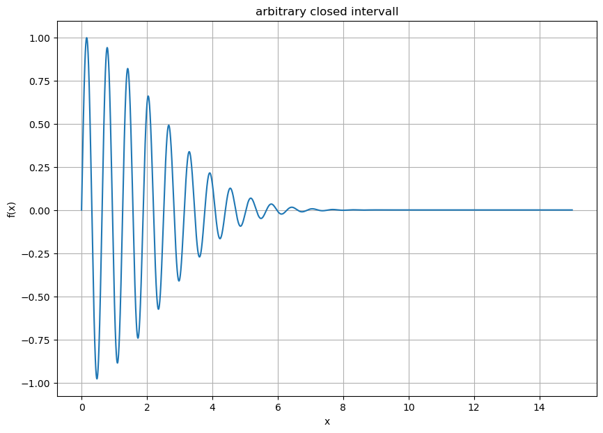

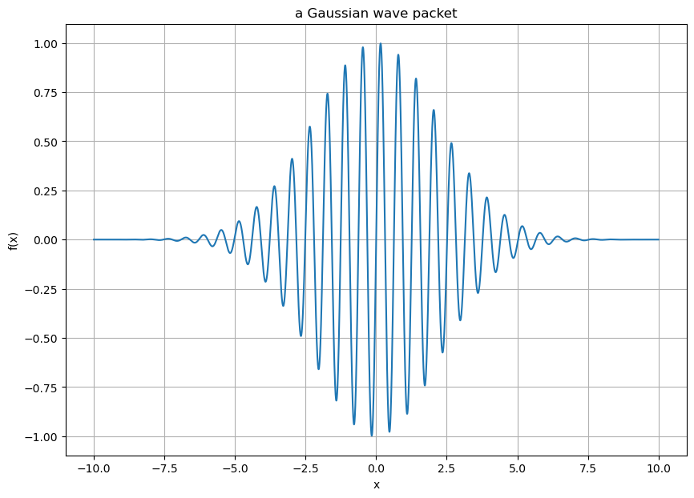

```python
def f(x, a=0.1, b=10):
    return np.sin(b*x)*np.exp(-a*x*x)

def arbitrary_closed_intervall(a=0,b=15, title='none'):
    x = np.linspace(a, b, 10000)
    y = f(x)
    plt.title(title)
    plt.xlabel("x")
    plt.ylabel("f(x)")
    plt.grid()
    plt.gcf().set_size_inches(10, 7)
    plt.plot(x,y)
    plt.show()
    return

arbitrary_closed_intervall(title='arbitrary closed intervall')
arbitrary_closed_intervall(a=-10,b=10, title='a Gaussian wave packet')
```

## Exercise 3 part I.2

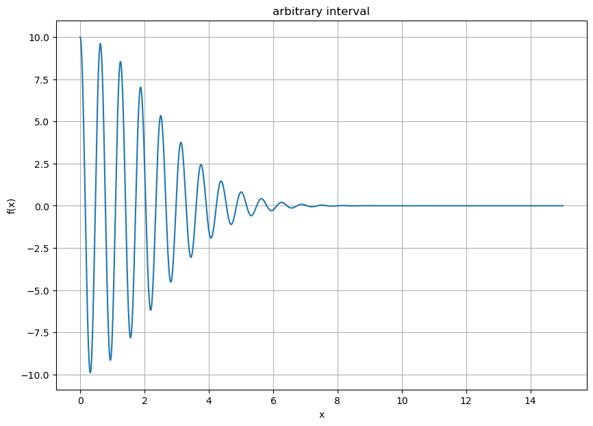

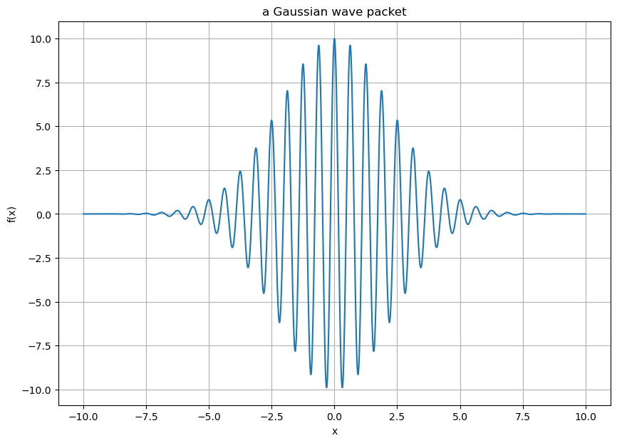

```python
# Exercise 3, Part I - part 2

def f_derivative(x, a=0.1, b=10):
    return b*np.cos(b*x)*np.exp(-a*x*x) - 2*a*x*np.sin(b*x)*np.exp(-a*x*x)

def arbitrary_closed_intervall_derivative(a=0,b=15, title='none'):
    x = np.linspace(a, b, 10000)
    y = f_derivative(x)
    plt.title(title)
    plt.xlabel("x")
    plt.ylabel("f(x)")
    plt.grid()
    plt.gcf().set_size_inches(10, 7)
    plt.plot(x,y)
    plt.show()
    return
arbitrary_closed_intervall_derivative(title='arbitrary interval')
arbitrary_closed_intervall_derivative(a=-10,b=10, title='a Gaussian wave packet')
```

## Exercise 3 part I.3

```python
def forward_difference_derivative(f, h=1e-2):
    return lambda x: (f(x + h) - f(x)) / h


def analytical_derivative_f(x, a=0.1, b=10):
    return b*np.cos(b*x)*np.exp(-a*x**2) - 2*a*x*np.sin(b*x)*np.exp(-a*x**2)


def f(x, a=0.1, b=10):
    return np.sin(b*x) * np.exp(-a * x**2)


print(f"{analytical_derivative_f(1)=}")
print(f"{forward_difference_derivative(f)(1)=}")
```

```
analytical_derivative_f(1)=-7.493783027703379
forward_difference_derivative(f)(1)=-7.220096595246589
```

## Exercise 3 part I.4

```python
def central_difference_derivative(f, h=1e-2):
    return lambda x: (f(x + h) - f(x - h)) / (2 * h)


print(f"{analytical_derivative_f(1)=}")
print(f"{forward_difference_derivative(f)(1)=}")
print(f"{central_difference_derivative(f)(1)=}")
```

```
analytical_derivative_f(1)=-7.493783027703379
forward_difference_derivative(f)(1)=-7.220096595246589
central_difference_derivative(f)(1)=-7.48156774953081
```

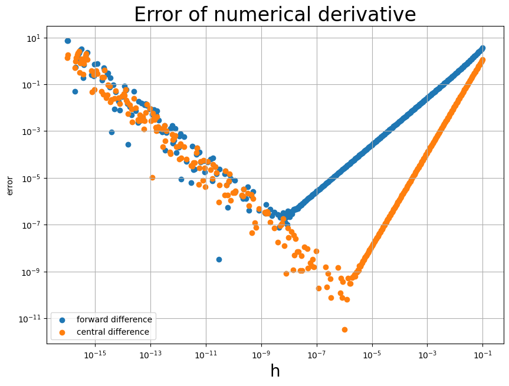

```python
# Exercise 3, Part I - part 5

h = np.logspace(-16,-1, num=500)
analytic_f_derivative = analytical_derivative_f(1)
numerical_forward_derivative_error = forward_difference_derivative(f, h)(1) - analytic_f_derivative
numerical_centraldifference_derivative_error = central_difference_derivative(f, h)(1) - analytic_f_derivative

# create scatter plot
plt.scatter(h, numerical_forward_derivative_error, label='forward difference')
plt.scatter(h, numerical_centraldifference_derivative_error, label='central difference')
plt.legend()
plt.grid()
plt.xlabel('h', size=20)
plt.ylabel('error')
# plt.xlim(10^(-16), 1)
plt.xscale('log')
plt.yscale('log')
plt.gcf().set_size_inches(10, 7)
plt.rc('font', size=20)
plt.title('Error of numerical derivative')
plt.show()
```

## Exercise 3 part II.1

```
0.8227663359156917
-0.49225065733419177
```

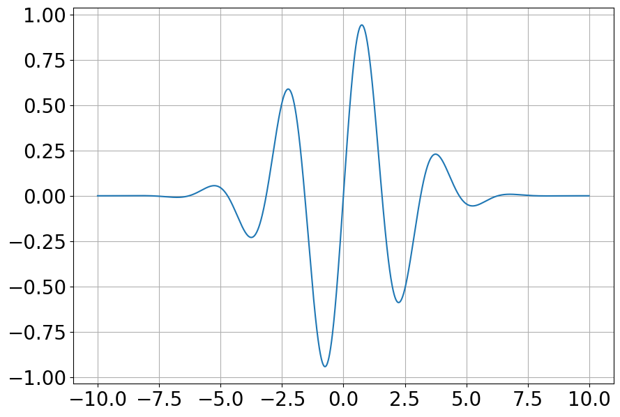

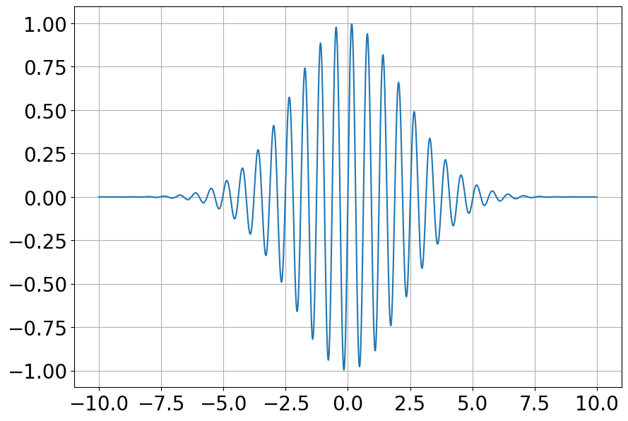

```python
class WavePacket:
    """
    A class representation of a wave packet-function.
    """
    def __init__(self, a, b):
        self.a = a
        self.b = b

    def f(self, x):
        return np.sin(self.b*x)*np.exp(-self.a*x*x)

    def plot(self, x_min=-10, x_max=10, dx=0.01):
        """
        A simple plotting routine for plotting f(x) in some range.
        """
        x = np.arange(x_min, x_max, dx)
        y = self.f(x)
        plt.gcf().set_size_inches(10, 7)
        plt.plot(x, y)
        plt.grid()
        fig = plt.figure()


# Create two WavePacket objects, having their own parameter values
WP1 = WavePacket(0.1, 2) # a=0.1, b=2
WP2 = WavePacket(0.1, 10) # a = 0.1, b=10

# Evaluate the two functions at a specific point
x = 1
print(WP1.f(x))
print(WP2.f(x))

# Plot the two functions
WP1.plot()
WP2.plot()
```

```
0.8227663359156917
-0.49225065733419177
```

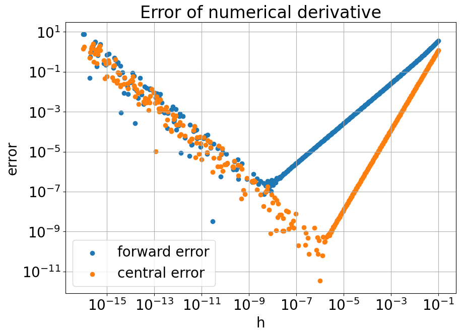

```python
class FancyWavePacket:
    """
    A slightly more fancy class representation of a wave packet-function.
    In this version, we define the dunder (double-underscore) method __call__,
    which lets us treat objects of the class as if they were real functions!
    """
    def __init__(self, a, b):
        self.a = a
        self.b = b

    def __call__(self, x):
        return np.sin(self.b*x)*np.exp(-self.a*x*x)

    def f_derivative(self, x):
        return self.b*np.cos(self.b*x)*np.exp(-self.a*x*x) - 2*self.a*x*np.sin(self.b*x)*np.exp(-self.a*x*x)

    def f_forward_derivative(self, x, h):
        return (f(x+h, self.a, self.b) - f(x, self.a, self.b))/h

    def f_centraldifference_derivative(self, x, h):
        return 0.5*(f(x+h, self.a, self.b) - f(x-h, self.a, self.b))/h

    def absolute_error_scatter(self, x, h):
        forward_error = self.f_forward_derivative(x, h) - self.f_derivative(x)
        centraldifference_error = self.f_centraldifference_derivative(x, h) - self.f_derivative(x)

        # create scatter plot
        plt.scatter(h, forward_error, label='forward error')
        plt.scatter(h, centraldifference_error, label='central error')
        plt.legend()
        plt.grid()
        plt.xlabel('h', size=20)
        plt.ylabel('error')
        plt.xscale('log')
        plt.yscale('log')
        plt.gcf().set_size_inches(10, 7)
        plt.rc('font', size=20)
        plt.title('Error of numerical derivative')
        plt.show()



WP1 = FancyWavePacket(0.1, 2) # a=0.1, b=2
WP2 = FancyWavePacket(0.1, 10) # a = 0.1, b=10
# Evaluate the two functions at a specific point
x = 1
print(WP1(x)) # If WP1 had been a function, the syntax would be the same here!
print(WP2(x)) # Again, we no longer have to type "WP2.f(x)", we can do "WP2(x)".


h = np.logspace(-16,-1, num=500)
WP3 = FancyWavePacket(0.1, 10)
WP3.absolute_error_scatter(x=x, h=h)
```

## Exercise 4 part 1

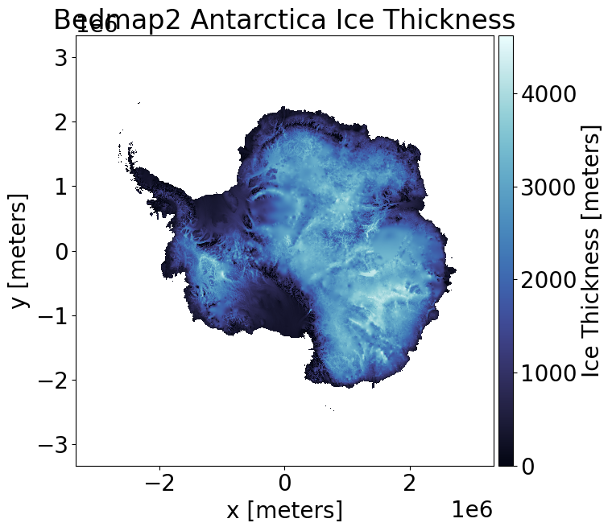

```python
import rockhound as rh
import matplotlib.pyplot as plt
import cmocean

# Load the ice thickness grid
bedmap = rh.fetch_bedmap2(datasets=["thickness"])
# print(bedmap)

plt.figure(figsize=(8, 7))
ax = plt.subplot(111)
pc = bedmap.thickness.plot.pcolormesh(
    ax=ax, cmap=cmocean.cm.ice, cbar_kwargs=dict(pad=0.01, aspect=30)
)
ax.set_title("Bedmap2 Antarctica Ice Thickness")
plt.tight_layout()
plt.show()
```

## Exercise 4 part 2

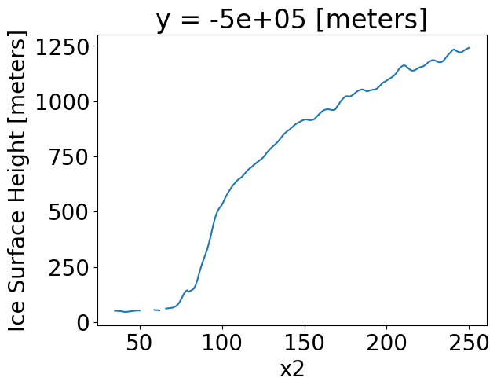

```python
# Extract cross section using the original coordinates
bedmap = rh.fetch_bedmap2(datasets=["thickness","surface","bed"])
bed1d = bedmap.sel(y=-0.5e6, x=slice(-1.6e6,-1.35e6))
# Add a second x-coordinate to make prettier plots
# (shift x-axis to start at zero, and convert from m to km)
bed1d = bed1d.assign_coords({"x2":((bed1d.x+1.6e6)/1e3)})
bed1d.surface.plot(x='x2')
```

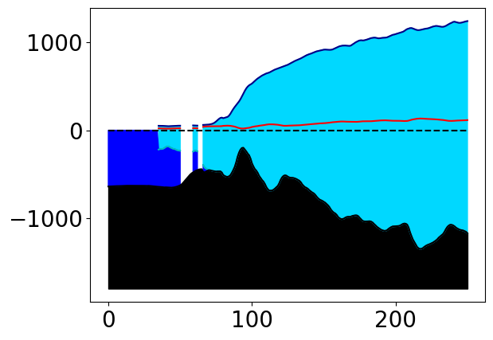

```python
rho_ice = 0.91
rho_water = 1.0
surface = bed1d.surface.values
thickness = bed1d.thickness.values
h = -(surface-thickness) * (rho_water/rho_ice - 1)

plt.figure()
ax = plt.subplot(111)
data_length = bed1d.bed.values.shape[0]

ax.plot(bed1d.surface.values, "#008")
ax.plot(np.zeros(bed1d.bed.values.shape), "--k")
ax.plot(h, "-r")
ax.plot(bed1d.surface.values - bed1d.thickness.values, "-c")
ax.plot(bed1d.bed.values, "-k")
ax.fill_between(np.arange(data_length), bed1d.bed.values, -1800 * np.ones(data_length), color="k")
ax.fill_between(np.arange(data_length),
                bed1d.surface.values,
                bed1d.surface.values - bed1d.thickness.values,
                color="#00d8ff")
ice_bottom = bed1d.surface.values - bed1d.thickness.values
first_valid_index = np.where(~np.isnan(ice_bottom))[0][0]
ice_bottom = np.r_[np.zeros(first_valid_index), ice_bottom[first_valid_index:]]
ax.fill_between(np.arange(data_length), ice_bottom, bed1d.bed.values, color="b")
```

We see a side plot of the Antarctic continent. In light blue is the ice, dark blue is the ocean and the bedrock is seen in black. The dotted line is "sea level". The red line is the freeboard level. Yes, the shape of the bedrock is important. Because the density of water is higher than the density of ice, more water can fit in deep bedrock trenches than the volume that the ice took up.

## Exericse 4 part 3

```python
rho_ice = 0.91
rho_water = 1.0
surface  = bedmap.surface.values
thickness = bedmap.thickness.values
h = - (surface - thickness)* ((rho_water/rho_ice) -1)

h2 = surface-h
h2 = h2[~np.isnan(h2)]

h_sum = np.sum(h2)

earth_covered_by_sea = 3.61*10**8

sea_level_rise = h_sum/earth_covered_by_sea
print(sea_level_rise)
```

```
74.30384022288526
```

Using our code we can come up with a rough estimate of SLR of 74.3 meters.

## Exercise 4 part 4

We can use bedmap data to more accurately predict how much the ice will contribute to sea level rise. If the Antarctic ice goes deep into a trench, the ice melting will have a lesser impact than if the bedrock were shallow. It impacts the freeboard level.

Some limitations include that we do not take into account land masses, the oval shape of the Earth, and the fact that the area of a sphere increases as you increase its radius. In this case, the area of Earth covered by sea would increase as the sea level itself increases.

## Conclusion

In this project we were presented with problems correlating to numerical errors in case of floating-point numbers, round-off errors and truncation errors. Moreover, we learned about different libraries I.e., rockhound library and cmocean libraries to handle large datasets. NumPy arrays were particularly useful because they simplify the code by using vectorized computation. Numpy makes it easy to implement Boolean masking because of its useful features and functions. Assignment presented us with exercises in which we plotted graphs of functions. Visual interpretation of a function made it easy for us to know how functions value change by tweaking its parameters and how trend of a function changes with different parameters. We also calculated derivatives and numerical derivatives and checked our estimates with analytical solution for our understanding. Using class made us realize how easy it becomes to re-use code and it also improves code readability. We learned how to create conda environment and install packages for that particular environment. While implementing assignment we got an overview of how python checks for dependencies between packages. Different virtual environments make it easy to work on separate projects and allow you to run separate python versions for projects.